# **DataSpace Work: LSD Consumption**

**Cap 2:**Multiclass Classification  
*Piero Cavalcanti - s252117*

# Classes, Libraries, and Instances for coding

#### Libraries

```python
# -*- coding: utf-8 -*-

print (__doc__)

from mpl_toolkits.mplot3d import Axes3D
from mlxtend.plotting import plot_decision_regions
from PIL import Image
from sklearn import preprocessing
from sklearn.model_selection import train_test_split
from sklearn.naive_bayes import GaussianNB
#from mlxtend.plotting import plot_decision_regions
from sklearn.decomposition import PCA
import numpy as np
import matplotlib.pyplot as plt
import matplotlib.colors as colours
import matplotlib.image as mpimg
import glob
import os
from random import randrange
from sys import getsizeof

import pandas as pd
import numpy as np
import matplotlib.pyplot as plt
from mpl_toolkits.mplot3d import Axes3D
from sklearn import datasets, svm
from sklearn.ensemble import RandomForestClassifier
from sklearn.model_selection import train_test_split
from sklearn.decomposition import PCA
from sklearn.metrics import accuracy_score, roc_auc_score, log_loss
from matplotlib.colors import Normalize
from sklearn.preprocessing import StandardScaler
from sklearn import decomposition
from sklearn.tree import export_graphviz
import pydot
from sklearn.model_selection import StratifiedShuffleSplit
from sklearn.model_selection import GridSearchCV
import random
import seaborn as sns
import csv
import time

from sklearn.naive_bayes import GaussianNB
from sklearn.svm import SVC
from sklearn.datasets import load_digits
from sklearn.model_selection import learning_curve
from sklearn.model_selection import ShuffleSplit
from sklearn import metrics

from sklearn.linear_model import LogisticRegression, LinearRegression
from sklearn import metrics

from sklearn.neighbors import KNeighborsClassifier

import matplotlib.pyplot as plt
import numpy as np
from sklearn import datasets, linear_model
import webbrowser

from sklearn.metrics import mean_squared_error, r2_score
from sklearn.feature_selection import SelectFromModel



import numpy as np
import matplotlib.pyplot as plt
from itertools import cycle

from sklearn import svm, datasets
from sklearn.metrics import roc_curve, auc
from sklearn.model_selection import train_test_split
from sklearn.preprocessing import label_binarize
from sklearn.multiclass import OneVsRestClassifier
from scipy import interp
```

```
Automatically created module for IPython interactive environment
```

#### Constraint Definition

- Seed 1
- Seed 2

Fixed Seeds for random operation

```python
Seed1= 25
Seed2= 2
```

- TestSize

Fixed dimension for the Test set

```python
TestSize=.2
```

Parameters dictionaries for different GridsearchCV made for the estimators used:

```python
weight_options = ['uniform', 'distance']
knn_params = dict(n_neighbors=list(range(1, 20)), weights=['uniform', 'distance'])
```

```python
rf_params = dict(
    n_estimators=[500], #originally [100,500,1000,1500]
    max_features=['auto', 'sqrt'],
    criterion= ['gini', 'entropy'],)
```

```python
C_range = [10**(-1),10**(0),10**(1)]
gamma_range = [10**(-1),10**(0),10**(1)]
rbf_svm_params = dict(gamma=gamma_range, C=C_range)
linear_svm_params = dict(C=C_range)
```

#### Function Definition

- *function*: plot_learning_curve()

given a set of parameters, such as estimator to be represented or train sizes for learning phases, it represent the evolution of learning stage in a two curves-based graph.

```python
def plot_learning_curve(estimator, title, X, y, ylim=None, cv=None,
                        n_jobs=None, train_sizes=np.linspace(.01, 1.0, 50)):

    plt.figure(figsize=(15,7))
    plt.title(title)
    if ylim is not None:
        plt.ylim(*ylim)
    plt.xlabel("Training examples")
    plt.ylabel("Score")
    train_sizes, train_scores, test_scores = learning_curve(
        estimator, X, y, cv=cv, n_jobs=n_jobs, train_sizes=train_sizes)
    train_scores_mean = np.mean(train_scores, axis=1)
    train_scores_std = np.std(train_scores, axis=1)
    test_scores_mean = np.mean(test_scores, axis=1)
    test_scores_std = np.std(test_scores, axis=1)
    plt.grid()

    plt.fill_between(train_sizes, train_scores_mean - train_scores_std,
                     train_scores_mean + train_scores_std, alpha=0.1,
                     color="r")
    plt.fill_between(train_sizes, test_scores_mean - test_scores_std,
                     test_scores_mean + test_scores_std, alpha=0.1, color="g")
    plt.plot(train_sizes, train_scores_mean, 'o-', color="r",
             label="Training score")
    plt.plot(train_sizes, test_scores_mean, 'o-', color="g",
             label="Cross-validation score")

    plt.legend(loc="best")
    return plt
```

- *function*: cross_validation()

function that made the GridSearch for the classifier (and with the setup parameters) and return the best estimator based on the Accuracy scores.

```python
def cross_validation(clf, clf_params,X,y):
    start = time.time()
    best_clf = GridSearchCV(estimator=clf,param_grid=clf_params, cv=5,scoring=None, return_train_score=True)
    best_clf.fit(X,y)
    end = time.time()
    print("Accuracy for result of cross validation:",best_clf.best_score_)
    print("Cross validation requires:",end-start,"sec")
    return best_clf.best_estimator_
```

- *function*: score_model()

helpful function that plot different statistics about the estimator such as time spent for both training and test and Accuracy and LogLoss score

```python
def score_model(clf,X,y,name):
    X_train, X_test, y_train, y_test = train_test_split(X,y,test_size = TestSize,random_state=Seed1)
    start_tr = time.time()
    clf.fit(X_train,y_train)
    training_time=time.time()-start_tr
    start_te = time.time()
    predictions = clf.predict_proba(X)
    lloss=metrics.log_loss(y_true=y,y_pred=predictions,labels=[0,1,2,3,4,5,6])
    accuracy=clf.score(X_test,y_test)
    test_time = time.time()-start_te
    score_res = []
    score_res.append(("Name",name))
    score_res.append(("Accuracy",accuracy))
    score_res.append(("Log Loss",lloss))
    score_res.append(("Training Time",training_time))
    score_res.append(("Test Time",test_time))
    print("Scores:")
    for name,result in score_res:
        print(name,"=",result)
    return score_res
```

- *function*: pca_smart_comp()

made a calculation to retrieve the PCA components

```python
def pca_smart_comp (pca_X,desired_perc):
    explained_variance = np.var(pca_X, axis=0)
    explained_variance_ratio = explained_variance / np.sum(explained_variance)
    cum=np.cumsum(explained_variance_ratio)
    print(cum)
    fi = plt.figure(figsize=(15,6))
    plt.plot(cum,'--o')
    plt.grid(True)
    plt.show()
    np.max(cum)
    desired=np.argmax(cum>desired_perc)
    print("Good Number of PC=",desired+1,"with Cumulative Variance =",cum[desired])
    return desired
```

- *function*: plot_multiclass_roc()

perform the Area Under ROC Curve calculation and visualization for multiclass estimator on the X (instance set) and y (label set) parameters.

```python
def plot_multiclass_roc(clf,X,y):

    lw = 1
    y = label_binarize(y, classes=[0,1,2,3,4,5,6])
    n_classes = y.shape[1]

    # shuffle and split training and test sets
    X_train, X_test, y_train, y_test = train_test_split(X, y, test_size=TestSize,random_state=Seed1)

    # Learn to predict each class against the other
    classifier = OneVsRestClassifier(clf)
    y_score = classifier.fit(X_train, y_train).predict_proba(X_test)


    # Compute ROC curve and ROC area for each class
    fpr = dict()
    tpr = dict()
    roc_auc = dict()
    for i in range(n_classes):
        fpr[i], tpr[i], _ = roc_curve(y_test[:, i], y_score[:, i])
        roc_auc[i] = auc(fpr[i], tpr[i])

    # Compute micro-average ROC curve and ROC area
    fpr["micro"], tpr["micro"], _ = roc_curve(y_test.ravel(), y_score.ravel())
    roc_auc["micro"] = auc(fpr["micro"], tpr["micro"])

    if n_classes>2:

        # First aggregate all false positive rates
        all_fpr = np.unique(np.concatenate([fpr[i] for i in range(n_classes)]))

        # Then interpolate all ROC curves at this points
        mean_tpr = np.zeros_like(all_fpr)
        for i in range(n_classes):
            mean_tpr += interp(all_fpr, fpr[i], tpr[i])

        # Finally average it and compute AUC
        mean_tpr /= n_classes

        fpr["macro"] = all_fpr
        tpr["macro"] = mean_tpr
        roc_auc["macro"] = auc(fpr["macro"], tpr["macro"])

        # Plot all ROC curves
        plt.figure(figsize=(10,10))
        plt.plot(fpr["micro"], tpr["micro"],
                 label='micro-average ROC curve (area = {0:0.2f})'
                       ''.format(roc_auc["micro"]),
                 color='deeppink', linestyle=':', linewidth=4)

        plt.plot(fpr["macro"], tpr["macro"],
                 label='macro-average ROC curve (area = {0:0.2f})'
                       ''.format(roc_auc["macro"]),
                 color='navy', linestyle=':', linewidth=4)

        colors = cycle(['aqua', 'darkorange', 'cornflowerblue','green','red','yellow','magenta'])
        for i, color in zip(range(n_classes), colors):
            plt.plot(fpr[i], tpr[i], color=color, lw=lw,
                     label='ROC curve of class {0} (area = {1:0.2f})'
                     ''.format(i, roc_auc[i]))

        plt.plot([0, 1], [0, 1], 'k--', lw=lw)
        plt.xlim([0.0, 1.0])
        plt.ylim([0.0, 1.05])
        plt.xlabel('False Positive Rate')
        plt.ylabel('True Positive Rate')
        plt.title(clf)
        plt.legend(loc="lower right")
        plt.show()
```

- *function*: normalize()

API function to perform the Normalization through StandardScaler (scikit.preprocessing) and then returns the Pandas Dataframe object

```python
def normalize(X):
    npX = np.asarray(X)
    npX = preprocessing.StandardScaler(copy=True,with_mean=True,with_std=True).fit_transform(npX) #Normalization
    return pd.DataFrame(npX)
```

# Beginning Stages

### Load the dataset

we are collecting the datas into a *pandas* **Dataframe** that gives you the possibility to work with great flexibility and enjoying the huge amount of methods that pandas provides for manipulate the datasets

```python
#charging datas from the data file
data = pd.read_csv("drug_consumption.data.txt", sep=",", header=None)
pd.options.display.max_columns = None
# row and column number
data.columns = ["ID", "Age","Gender","Education", "Country","Ethnicity", "Nscore","Escore","Oscore","Ascore","Cscore","Impulsive", "SS","Alcohol","Amphet","Amyl","Benzos","Caff","Cannabis","Choc" , "Coke", "Crack", "Ecstasy", "Heroin", "Ketamine", "Legalh", "LSD", "Meth", "Mushrooms", "Nicotine", "Semer", "VSA"]
print("Columns:",len(data.columns))
print("Rows:",data.ID.count())
```

```
Columns: 32
Rows: 1885
```

### First look at the Dataset

By using the *pandas* interfaces function, we can collect some information about the dimensions, the types, and others details about the Dataset we choosed.

Generate an understandable copy of dataset, replacing the numerical values with the referred definitions (for particular values).

```python
#Generate the Categorical definition, instead of numerical
#charging datas from the data file
data_str = pd.read_csv("drug_consumption_str.data.txt", sep=",", header=None)
# row and column
data_str.columns = ["ID", "Age","Gender","Education", "Country","Ethnicity", "Nscore","Escore","Oscore","Ascore","Cscore","Impulsive", "SS","Alcohol","Amphet","Amyl","Benzos","Caff","Cannabis","Choc" , "Coke", "Crack", "Ecstasy", "Heroin", "Ketamine", "Legalh", "LSD", "Meth", "Mushrooms", "Nicotine", "Semer", "VSA"]
```

### Classification Problem Definition

So, we have to define our classification problem, by choosing a class to be object of our prediction, and in which form it will be given, depending on the classification algorithm it will provides.

Thus, I select the **LSD Consumption** as the feature used for classification problem.

We will provides 2 kind of work for make the prediction:

- trying to predict Seven class classification
- trying to predict two class classification by using a binary trasformation of the feature as shown before ("Never Used", "Used over a Decade Ago" and "Used in last Decade" form class "Non-user" and all other classes form class "User".)

### Data Manipulation for ML Analysis

we will now extract our "LSD" as the label array (y)

```python
if "ID" in data.columns : data = data.drop(["ID"],axis=1)
```

```python
y = data["LSD"]
print(y.shape, "diff values:", len(y.unique()))
X = data.drop("LSD",axis=1)
print(X.shape)
```

```
(1885,) diff values: 7
(1885, 30)
```

than generate the training and test set.

```python
X_train, X_test, y_train, y_test = train_test_split(X,y,test_size = TestSize,random_state=Seed1)
print(X_train.shape, X_test.shape, y_train.shape, y_test.shape)
print( np.unique(y_train), np.unique(y_test))
feature_list = list(X.columns)
```

```
(1508, 30) (377, 30) (1508,) (377,)
[0 1 2 3 4 5 6] [0 1 2 3 4 5 6]
```

here, we define the same operation for **binary classification problem:**

```python
label_kv = {('Never Used', 0), ('Used over a Decade Ago', 1),('Used in Last Decade', 2),('Used in Last Year', 3),
            ('Used in Last Month', 4), ('Used in Last Week', 5), ('Used in Last Day', 6)}
labels_def = ['Never Used','Used over a Decade Ago','Used in Last Decade','Used in Last Year',
            'Used in Last Month','Used in Last Week','Used in Last Day']
bin_labels_def = ['No User','User']

#y_bin for 2-Category Classification Problem:
#'never used', 'Used over a Decade Ago' and 'Used in Last Decade' correspond to 0 ("Not User"), otherwise 1 ("User")
y_bin = pd.Series([int(item > 1) for item in y], name="LSD (2)")
```

```python
X_train, X_test, y_bin_train, y_bin_test = train_test_split(X,y_bin,test_size = TestSize,random_state=Seed1)
print(X_train.shape, X_test.shape, y_bin_train.shape, y_bin_test.shape)
print(y_bin_test.unique(),y_bin_train.unique())
```

```
(1508, 30) (377, 30) (1508,) (377,)
[1 0] [1 0]
```

## K-fold Cross Validation

**Cross Validation** is the technique used to lead the model selection by overpassing the problem to be not able to estimate the test error rate: that's becouse, even if we have a Test Set, we cannot use it for model selection, becouse it will compromise his *purity* for model test and assestement phase. So in all the stages that precede the achievement of the model result, it is **avoid to use Test set**. For this reason a good way to approximate the Test set is to split another time the Training Set, to get a subset of instances, the *Validation Set* used for Paramater Evaluation and/or for model selection. This is the main idea. **K-fold CV** is a more complex application of this technique, that involves randomply dividing the set of observations into k groups, or folds, of approximately equal size: the first fold is treated as the Validation Set, and the model is fit on the remaining k-1 folds. The the **MSE** (mean squared error) is used to measure how the model is working. This procedure is repeated k times; where each time the Validation Set is represented by a different folds, until everyone is used as ValSet. So, said the MSE: $$MSE=\: \sigma \: ^{2}\: /\: n$$ The k-fold CV estimate is computed by averaging these values: $$CV_{(k)}=\: \frac{1}{k}\sum_{1}^{k}\sigma \: ^{2}\: /\: n$$

The K-Fold CV is preferred to the Leave-One-Out Technique (that correspond to the K-Fold for k = # of instances) becouse of computational time: K-Fold is good compromise between the exhaustive research and a quick-computation research.

We will use CV with k=5 by usage of GridSearchCV method provided by SKLEARN library.

# Multiclass Classification

We will use as parameter of evaluation:

$Accuracy = \frac{TP + TN}{TP + FP + TN + FN}$

Accuracy, or Error Rate, describes the percentage of correct predictions made by the model. In short words, Accuracy = # correct / total predictions.

$Log Loss = -\sum_{c=1}^My_{o,c}\log(p_{o,c})$

where:

- N - number of observations
- M - number of possible class labels (dog, cat, fish)
- log - the natural logarithm
- y - a binary indicator (0 or 1) of whether class label c is the correct classification for observation o
- p - the model's predicted probability that observation o is of class c

we take the sum of log loss values for each class prediction in the observation. Logarithmic loss measures the performance of a classification model where the prediction input is a probability value between 0 and 1. The goal of our machine learning models is to minimize this value. A perfect model would have a log loss of 0. *Log loss increases as the predicted probability diverges from the actual label.*

$Training Time$

Time spent to *train* the model

$Test Time$

Time spent to *use* the model on testset

### Log Loss vs Accuracy

- *Accuracy* is the count of predictions where your predicted value equals the actual value. Accuracy is not always a good indicator because of its yes or no nature. Goal = get the *highest* accuracy possible.
- *Log Loss* takes into account the uncertainty of your prediction based on how much it varies from the actual label. This gives us a deeper view into the performance of our model. Goal = get the *lowest* logarithmic loss possible.

Here, in **Classifiers and Scores** will be respectively stored the Estimator retrieved by the CrossValidation methods, and the score produced by function *score_model()* that realize a standard "benchmarking" for a fair evaluation of the different performances of the databases

```python
Classifiers=[]
Scores=[]
```

## Random Forest

**Random Forest** is a supervised learning algorithm. It is an ensemble methods based on the generation of a number of Decision Trees (defined by an hyperparameter) on the training samples. Each of these are made by choosing, at each node of the tree, one feature from a subset of *m randomly selected features*, different at each step. It sounds illogical (we cannot choose the best one, but just one from the random subset) but it improves the predictive accuracy and controls *over-fitting,* particularly when there are strong predictors (so correlated to the prediction goal).

**Ensemble methods** are meta-algorithms that combine several machine learning techniques into one predictive model in order to decrease variance (bagging), bias (boosting), or improve predictions (stacking).

Random forest retrieve then the most reliable **Classification Tree** that can be extracted from the class object as *best estimator* parameter. A decision tree can be used to visually and explicitly represent decisions and decision making, representing a tree-like model of decisions. The task of growing a classification tree is based on the use of *recursive binary splitting* to grow a classification tree. Splitting phase needs a way to detect how a particular split is going to give improvements to the research or it is a trivial solution.

The splitting, so, is generally based on those *impurity measures*:

*classification error* at a node t defined as $Error(t)={1}-\max{j}{P}{\left({j}{|}{t}\right)}$

*gini index* at a node t defined as $\displaystyle{G}{I}{N}{I}{\left({t}\right)}={1}-∑{j}{P}{\left({j}{|}{t}\right)}{2}$

*entropy index* at a node t defined as $\displaystyle{E}{n}{t}{r}{o}{p}{y}{\left({t}\right)}=-∑{j}{P}{\left({j}{|}{t}\right)} \log{{\left({P}{\left({j}{|}{t}\right)}\right)}}$

where P(j|t) is the probability that a record at the node t belongs to the class j.

In particular, since classification error is not sufficiently sensitive for tree-growing, *Gini Index (or Entropy) is used in practice.* It is not hard to see that the Gini index takes on a small value if all of the ˆpmk’s are close to zero or one. For this reason the Gini index is referred to as a measure of node purity—a small value indicates that a node contains predominantly observations from a single class.

A relevant issue about tree models is **overfitting**. This bad phenomenon may happen especially when we let the tree to become a fully-grown tree. **Random Forest** leads to perform, with the ensemble approach, a more generalized decision tree and generally prevent strong form of overfitting.

```python
rf = RandomForestClassifier()
clf = cross_validation(rf,rf_params,X_train,y_train)
start = time.time()
clf.fit(X_train, y_train)
end = time.time()
print('time required for whole process:',end-start,'sec', "\nN of features:",clf.n_features_)
print(round(clf.score(X_test, y_test),4)*100,"% accuracy on TEST SET, for",len(y_test.unique()),"different classes")
```

```
Accuracy for result of cross validation: 0.7108753315649867
Cross validation requires: 50.03192472457886 sec
time required for whole process: 2.8503053188323975 sec
N of features: 30
70.03 % accuracy on TEST SET, for 7 different classes
```

```python
print(clf)
```

```
RandomForestClassifier(bootstrap=True, class_weight=None, criterion='entropy',
            max_depth=None, max_features='auto', max_leaf_nodes=None,
            min_impurity_decrease=0.0, min_impurity_split=None,
            min_samples_leaf=1, min_samples_split=2,
            min_weight_fraction_leaf=0.0, n_estimators=500, n_jobs=1,
            oob_score=False, random_state=None, verbose=0,
            warm_start=False)
```

So let's see an example of **Decision Tree** by extracting randomly one of the estimator produced by RandomForest

```python
# Pull out one tree from the forest
tree = clf.estimators_[5]
# Export the image to a dot file
export_graphviz(tree, out_file = 'tree.dot', feature_names = feature_list, rounded = True, precision = 1)
# Use dot file to create a graph
(graph, ) = pydot.graph_from_dot_file('tree.dot')
# Write graph to a png file
graph.write_png('tree.png')
print("Image generated and saved as *tree.png*")
```

```
Image generated and saved as *tree.png*
```

```python
if webbrowser.open('tree.png'):
    print("Image opened on your OS")
```

```
Image opened on your OS
```

**Tree Graph Interpretation**:

### Learning Curve

In a learning curve, the performance of a model both on the training and validation set is plotted as a function of the training set size.

**Learning curves** further allow to easily illustrate the concept of (statistical) bias and variance.

**Bias** in this context refers to erroneous (e.g. simplifying) model assumptions, which can cause the model to *underfit* the data, cause by approximation of a real-life problem. A high-bias model does not adequately capture the structure present in the data.

**Variance** on the other hand quantifies how much the model varies as we change the training data. A high-variance model is very sensitive to small fluctuations in the training data, which can cause the model to overfit.

The amount of bias and variance can be estimated using **learning curves**:

- A model exhibits **high variance, but low bias** if the training score plateaus at a high level while the validation score at a low level, i.e., if there is a large gap between training and validation score.
- A model with **low variance but high bias**, in contrast, is a model where both training and validation score are low, but similar. Very simple models are high-bias, low-variance while with increasing model complexity they become low-bias, high-variance.

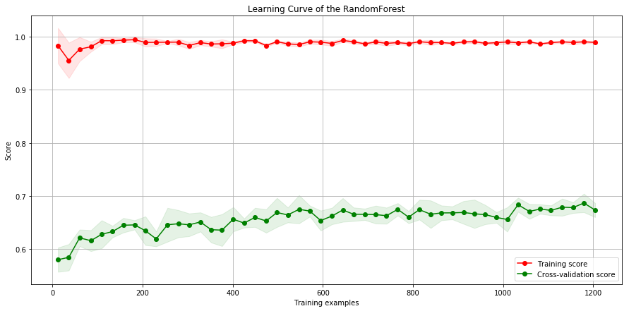

```python
plot_learning_curve(rf, "Learning Curve of the RandomForest", X_train, y_train, cv=5)
plt.show()
```

The *Learning Curve* represent the trend of the training phase for each instance of Training. The red represent the *score* (in this case, the Accuracy) on training set, the green the one reached in the cross-validation on the validation set.

In this case, it is clear that **Random Forest represent an high variance-low bias model**, becouse of the large gap between curves, and it means that is very sensitive to small fluctuations in the training data, and problably it overfit. It is an obvious demonstration of the unflexibility of Decision Tree.

```python
score_m = score_model(X=X,y=y,clf=clf,name="RandomForestClassifier")
Scores.append(score_m)
Classifiers.append(clf)
RFs = []
RFs.append(score_m)
```

```
Scores:
Name = RandomForestClassifier
Accuracy = 0.7082228116710876
Log Loss = 0.29112171792981956
Training Time = 2.787353515625
Test Time = 0.45592713356018066
```

### Feature Importance

**feature importance** is a method provided by Random Forest to describe how features affects the classification in the Decision trees ensemble. So it is a first indicator of how much feature are relevant in classification and how much are quite useless. That's becouse evaluate ensemble methods is so difficult: for this reason, it is provided an overall summary of the importance of each predictor (using the cumulative decrement of **Gini Index**).

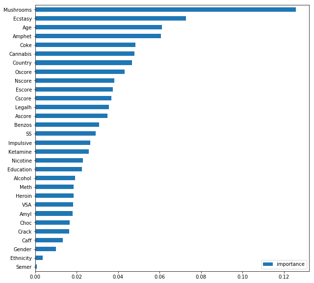

|  | importance |
| --- | --- |
| count | 30.000000 |
| mean | 0.033333 |
| std | 0.024423 |
| min | 0.000830 |
| 25% | 0.018252 |
| 50% | 0.027863 |
| 75% | 0.041790 |
| max | 0.125773 |

```python
feature_importances = pd.DataFrame(clf.feature_importances_,
                                   index = X_train.columns,
                                    columns=['importance']
                                  ).sort_values('importance',ascending=True)
feature_importances.plot.barh(rot=0, figsize=(10,10), align='center')
plt.show()
feature_importances.describe()
```

```python
print("MIN:",feature_importances.importance.first_valid_index(),feature_importances.importance.min())
print("MAX:",feature_importances.importance.last_valid_index(),feature_importances.importance.max())
```

```
MIN: Semer 0.0008298957801527766
MAX: Mushrooms 0.1257732633356347
```

Looking at feature importance, it is clear that there is a quite importance-balanced dataset, excluding the Max (Mushrooms) that show an importance larger that the double of the 4th most important feature. As predictable, if we eliminate the less important predictors, such as Semer or Ethnicity, the accuracy will decrease (but slightly) and the time will become shorter.

### Attempt with Reduced Features for RF

```python
reduced_X = SelectFromModel(clf,threshold=feature_importances.std()).fit_transform(X,y)
print("Reduced X dimension",reduced_X.shape,"against previous:",X.shape)
```

```
Reduced X dimension (1885, 17) against previous: (1885, 30)
```

```python
RFs.append(score_model(clf,reduced_X,y,"RandomForestClassifier (F.Imp.)"))
```

```
Scores:
Name = RandomForestClassifier (F.Imp.)
Accuracy = 0.7055702917771883
Log Loss = 0.2860300605515037
Training Time = 2.7336084842681885
Test Time = 0.43793582916259766
```

## PCA

Principal component analysis (PCA) is a statistical procedure that uses an orthogonal transformation to convert the variables of a dataset into a new set of variables which are linearly uncorrelated and called principal components. The principal components are ranked according to the variance of data along them. This technique can be used to reduce the dimensionality of the dataset by considering just the most important principal components.

So basically, PCA is a procedure that convert each instance of the dataset into its **principal components**: the first principal component has the largest possible variance, while the succeeding ones in turn has the highest variance possible under the constraint that it is orthogonal to the preceding components. Variance, informally, measures how far a set of values are spread out from their average value. So it, in short words, works as "summary" of the data designed to preserve the maximum informations possible with the dimensionality reduction choosen.

In order to reduce the dimensionality of a dataset $X$ with $n$ variables to a new dataset with $k$ variables using **PCA** the following steps have to be followed:

- standardize the data
- calculate the Eigenvectors and Eigenvalues from the covariance matrix or correlation matrix, or perform Singular Vector Decomposition.
- sort the Eigenvectors according to their Eigenvalues in decreasing order
- build the $n×k$-dimensional projection matrix $W$ by putting the top $k$ Eigenvectors into the columns of $W$
- transform the dataset $X$ by multiplying it with $W$: $X_{t} = XW$
- We apply PCA to the dataset in order to reduce the number of features.

```python
npX = np.asarray(X)
npX = preprocessing.StandardScaler(copy=True,with_mean=True,with_std=True).fit_transform(npX) #Normalization
pca_X = decomposition.PCA(n_components=30,svd_solver ='full').fit_transform(npX)
print("PCA reduction shape:",pca_X.shape,"VS original shape:",X.shape)
```

```
PCA reduction shape: (1885, 30) VS original shape: (1885, 30)
```

The **total variance** is the sum of variances of all individual principal components. The fraction of **variance explained** by a principal component is the ratio between the variance of that principal component and the total variance. For several principal components, add up their variances and divide by the total variance. So it means that the explained variance is a good measure of how the data are "well-resumed" by the PCA trasformation.

The most significant approach is to choose a reasonable value for cumulative variance and taking the principal components consequently; e.g. taking the first k eigenvectors that capture at least 90% of the total variance.

```
[0.24102946 0.31129327 0.36566335 0.41621334 0.46137004 0.50167167
 0.53796574 0.57243124 0.60536448 0.63654592 0.66675844 0.69495131
 0.72228455 0.74778413 0.77148436 0.79470201 0.81586682 0.83566204
 0.85441949 0.87186576 0.88815597 0.90310752 0.91788765 0.9321621
 0.94590268 0.9586019  0.96965321 0.97998311 0.99016363 1.        ]
```

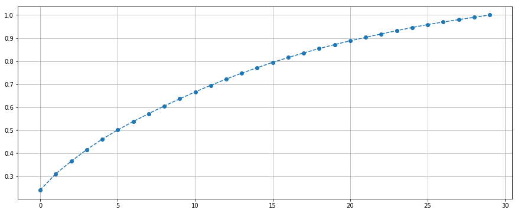

```
Good Number of PC= 22 with Cumulative Variance = 0.9031075205507343
```

```python
n_components = pca_smart_comp(pca_X,0.90)
```

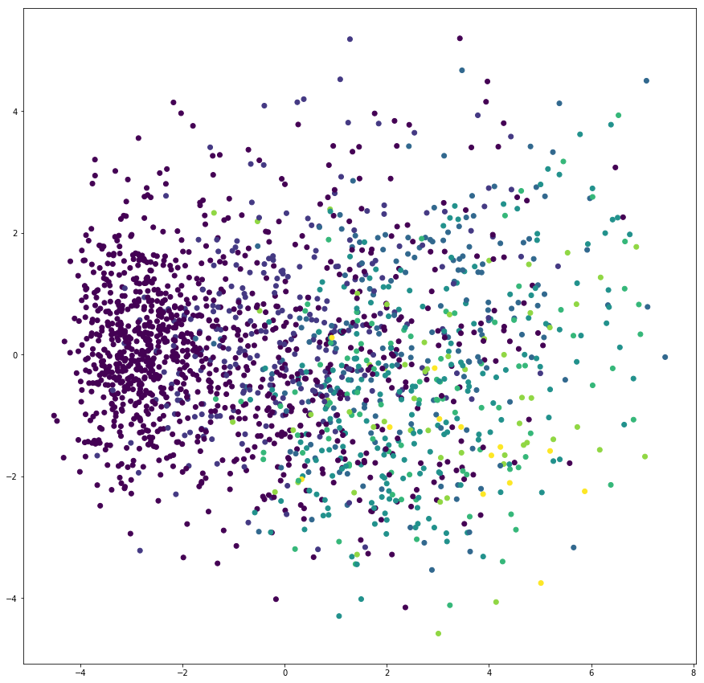

```python
plt.figure(figsize=(15,15))
plt.scatter(pca_X[:,0],pca_X[:,1],c=y)
plt.show()
```

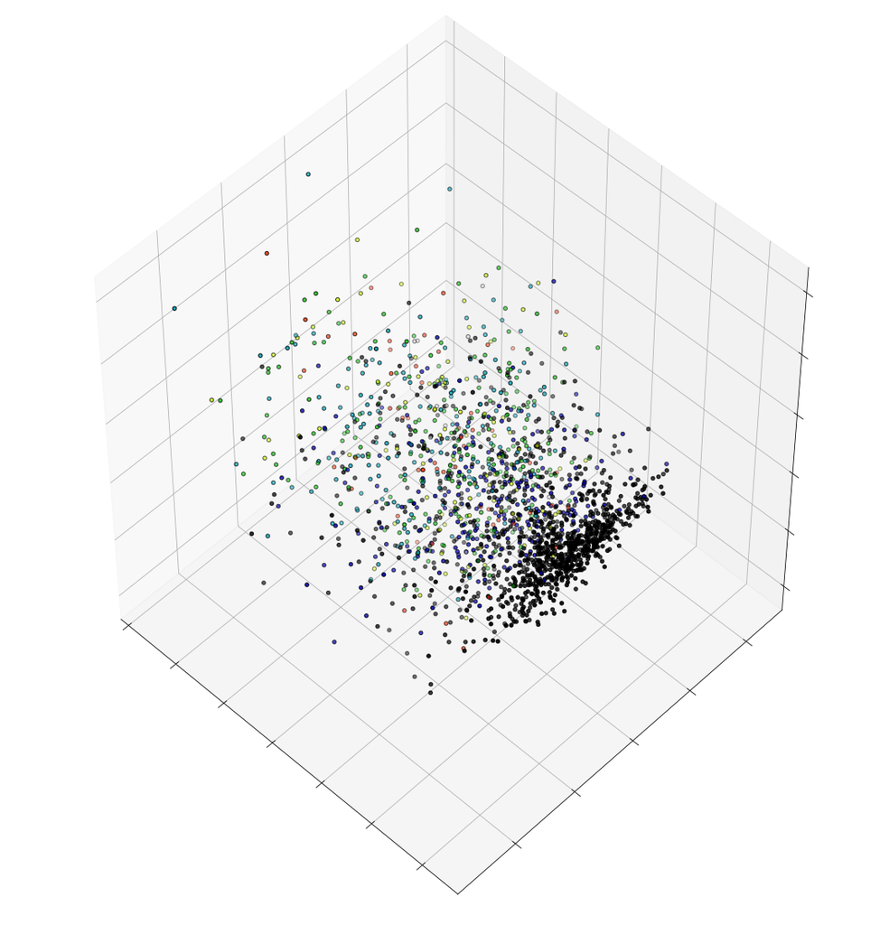

```python
fig = plt.figure(1, figsize=(15, 15))
plt.clf()
ax = Axes3D(fig, rect=[0, 0, .95, 1], elev=48, azim=134)
ax.scatter(pca_X[:, 0], pca_X[:, 1], pca_X[:, 2], c=y, cmap=plt.cm.nipy_spectral,
           edgecolor='k')
ax.w_xaxis.set_ticklabels([])
ax.w_yaxis.set_ticklabels([])
ax.w_zaxis.set_ticklabels([])
plt.show()
```

The graphs behind represent the scatter distribution of the datapoints projected on the 2 and the 3 principal components.

#### An attempt with RandomForestClassifier

```python
RFs.append(score_model(clf=clf,X=pca_X[:,0:n_components],y=y,name="RandomForestClassifier (PCA)"))
```

```
Scores:
Name = RandomForestClassifier (PCA)
Accuracy = 0.623342175066313
Log Loss = 0.3555725785851941
Training Time = 9.471132755279541
Test Time = 0.4451436996459961
```

```python
score_model(clf=clf,X=pca_X[:,0:n_components],y=y,name="RandomForestClassifier (PCA)")
```

```
Scores:
Name = RandomForestClassifier (PCA)
Accuracy = 0.636604774535809
Log Loss = 0.3523302512274428
Training Time = 9.487242460250854
Test Time = 0.44022130966186523
```

```
[('Name', 'RandomForestClassifier (PCA)'),
 ('Accuracy', 0.636604774535809),
 ('Log Loss', 0.3523302512274428),
 ('Training Time', 9.487242460250854),
 ('Test Time', 0.44022130966186523)]
```

## Resuming of Dataset Reduction

Here we can see a brief review of results of the estimation of RandomForest on different dataset.

```
                                  *****************
                                  Name = RandomForestClassifier
                                  Accuracy = 0.7082228116710876
                                  Log Loss = 0.29112171792981956
                                  Training Time = 2.787353515625
                                  Test Time = 0.45592713356018066
                                  *****************
                                  Name = RandomForestClassifier (F.Imp.)
                                  Accuracy = 0.7055702917771883
                                  Log Loss = 0.2860300605515037
                                  Training Time = 2.7336084842681885
                                  Test Time = 0.43793582916259766
                                  *****************
                                  Name = RandomForestClassifier (PCA)
                                  Accuracy = 0.623342175066313
                                  Log Loss = 0.3555725785851941
                                  Training Time = 9.471132755279541
                                  Test Time = 0.4451436996459961
```

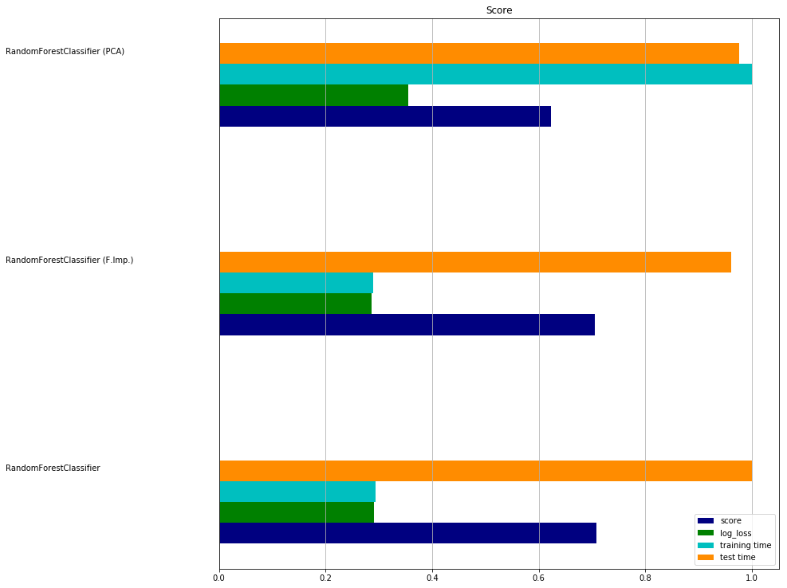

```python
for scores in RFs:
    print("                                  *****************")
    for name,result in scores:
        print("                                 ",name,"=",result)

scores=[]
for n in range(len(RFs)):
    scores.append(list(zip(*RFs[n]))[1])


# make some plots

indices = np.arange(len(scores))
clf_names = [x[0] for x in scores]
score = [x[1] for x in scores]
log_loss = [x[2] for x in scores]
training_time = [x[3] for x in scores]
test_time = [x[4] for x in scores]
training_time = np.array(training_time) / np.max(training_time)
test_time = np.array(test_time) / np.max(test_time)



plt.figure(figsize=(15, 8))
plt.title("Score")
plt.barh(indices, score, .1, label="score", color='navy')
plt.barh(indices + .1, log_loss, .1, label="log_loss",
         color='g')
plt.barh(indices + .2, training_time, .1, label="training time",
         color='c')
plt.barh(indices + .3, test_time, .1, label="test time", color='darkorange')
plt.yticks(())
plt.grid()
plt.legend(loc='best')
plt.subplots_adjust(left=.25)
plt.subplots_adjust(top=1.25)
plt.subplots_adjust(bottom=.05)

for i, c in zip(indices, clf_names):
    plt.text(-.4, i+.3, c)

plt.show()
```

Comparison on different dataset reduction give us an overview on the methods used for Feature Selection (or Dimensionality Reduction) to gain in efficiency (and to fight against the *curse of Dimensionality*). In this case, PCA do not represent a good solution for dimensionality reduction: both training and test time and accuracy of the model are not improved. On the other hand, reduce the features in terms of Random Forest's Feature Importance perform good statistics in terms of times spent and capability of the model. So could be a valid choice to use the reduced_X as the "official" instance matrix for our classifiers.

### AUC ROC Curve

Let introduce AUC-ROC Curve, that here is just shown by way of example for SVM Classifiers, but in the third part will be used for evaluation. That's becouse it is a meaningfull evaluation technique but not so easy-to-understand for Multiclass classification problem. We will see it more deeply in Binary Classification Paragraph.

**AUC (Area Under The Curve) ROC (Receiver Operating Characteristics) curve** is one of the most important evaluation metrics for checking any classification model’s performance. To define this, we define the following two metrics:

True positive rate (TPR): this is the same as the **recall**: $TPR = \frac{TP}{FN + TP}$

False positive rate (FPR): this corresponds to the proportion of negative data points that are mistakenly considered as positive, with respect to all negative data points: $FPR = \frac{FP}{TN + FP}$

ROC is a probability curve and AUC represents degree or measure of separability. It tells how much model is capable of distinguishing between classes. Higher the AUC, better the model is at predicting the correct class for each istance.

The ROC curve is plotted with TPR against the FPR where TPR is on y-axis and FPR is on the x-axis.

An excellent model has AUC near to the 1 which means it has good measure of separability. A poor model has AUC near to the 0 which means it has worst measure of separability. In fact it means it is reciprocating the result.

*The AUC, briefly, represent the amount of probability that a single instance with state of nature "1" will be well classified (as "1") against the probability that a single instance with state of nature "0" will be wrongly classified as "1", so it is a king of measurement of capability of discerness between class-members vs other instances.*

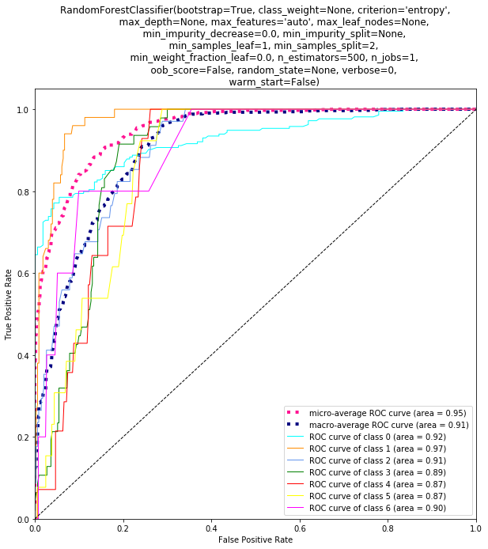

```python
plot_multiclass_roc(X=X,clf=clf,y=y)
```

### Dataset Comparison

So **which dataset is better to be used?** By one side, PCA show to not be the best reduction method for this dataset, while ReducedX (feature popped out by feature importance analysis) and the whole X perform similar performances when applied at classifier. So let's compare this two one to extract the best one:

```python
#CONDITION: accuracy and logloss of RF on whole dataset (RF[0]) are less competitive than the RF on reducedX (RF[1])
reduced_is_better = RFs[0][1][1] <= RFs[1][1][1] and RFs[0][2][1] >= RFs[1][2][1]
                    #-------ACCURACY---------#     #------------LOGLOSS--------#

print("Is reduced dataset better?" , reduced_is_better)

if reduced_is_better :
    X = reduced_X
    X_train, X_test, y_train, y_test = train_test_split(X,y,test_size = TestSize,random_state=Seed1)
print("DATASET USED:")
print(X_train.shape, X_test.shape, y_train.shape, y_test.shape)
print( np.unique(y_train), np.unique(y_test))
```

```
Is reduced dataset better? False
DATASET USED:
(1508, 30) (377, 30) (1508,) (377,)
[0 1 2 3 4 5 6] [0 1 2 3 4 5 6]
```

## K-Nearest Neighbor

Given a positive integer $K$ and a test observation $x$, the **KNN classifier** first identifies the K points in the training data that are closest to $x$, represented by $N_{0}$. It then estimates the conditional probability for class $j$ as the fraction of points in $N_{0}$ whose response values equal $j$:

$$Pr(Y = j | X = x_{0})=\frac{1}{K}\sum_{i \epsilon N_{0}}I(y_{i} = j)$$

Finally, KNN applies Bayes rule and classifies the test observation to the class with the largest probability. K-NN is a type of instance-based learning, or lazy learning, means that the model does not purely "learn" from training set, but measure some (k) distances from neighbours

**The KNN Algorithm:**

1. Load the data
2. Initialize K to your chosen number of neighbors
3. For each example in the data
   - Calculate the distance between the query example and the current example from the data.
   - Add the distance and the index of the example to an ordered collection
4. Sort the ordered collection of distances and indices from smallest to largest (in ascending order) by the distances
5. Pick the first K entries from the sorted collection
6. Get the labels of the selected K entries
7. If regression, return the mean of the K labels
8. If classification, return the mode of the K labels

Both for classification and regression, a useful technique can be used to assign weight to the contributions of the neighbors, so that the nearer neighbors contribute more to the average than the more distant ones.

In our CV, we will test several K values and two different approaches: weighted and standard.

*Parameters used for CrossValidation*:

- **n_neighbors** : int, optional (default = 5) Number of neighbors to use by default for kneighbors queries.
- **weights** : str or callable, optional (default = ‘uniform’) weight function used in prediction. Possible values:
  - ‘uniform’ : uniform weights. All points in each neighborhood are weighted equally.
  - ‘distance’ : weight points by the inverse of their distance. in this case, closer neighbors of a query point will have a greater influence than neighbors which are further away.

```python
knn = KNeighborsClassifier()
#X_train, X_test, y_train, y_test = train_test_split(X,y,test_size = TestSize,random_state=Seed1)
best_knn = cross_validation(clf=knn,clf_params=knn_params, X=X_train,y=y_train)
```

```
Accuracy for result of cross validation: 0.6405835543766578
Cross validation requires: 32.52998876571655 sec
```

```python
Scores.append(score_model(X=X,y=y,clf=best_knn,name="KNN"))
Classifiers.append(best_knn)
```

```
Scores:
Name = KNN
Accuracy = 0.6206896551724138
Log Loss = 1.066950619681932
Training Time = 0.004289388656616211
Test Time = 0.30907130241394043
```

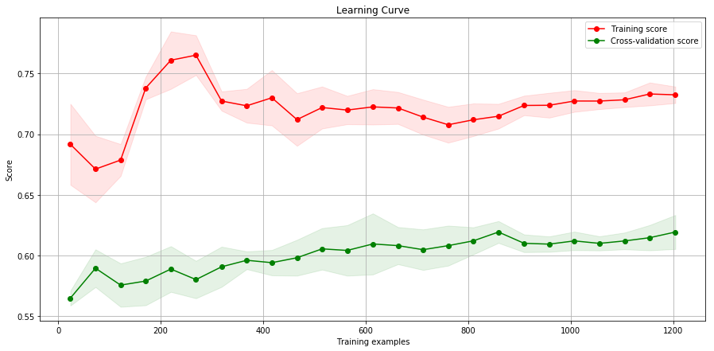

```python
plot_learning_curve(knn, "Learning Curve", X_train, y_train, cv=5,train_sizes=np.linspace(.02, 1.0, 25) )
plt.show()
```

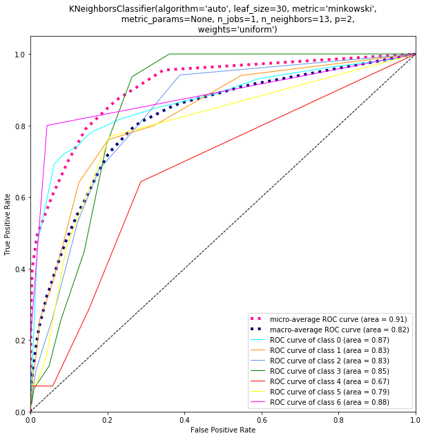

```python
plot_multiclass_roc(X=X,clf=best_knn,y=y)
```

### KNN with PCA?

K-nearest neighbor is based on measure of distance (similarity) and for this reason is strongly related to problem of dimensionality (curse). For this reason could be interesting to evaluate performances using a strong dimensionality reduction tool such as PCA

```python
score_model(clf=best_knn,X=pca_X[:,0:n_components],y=y,name="KNN (PCA)")
```

```
Scores:
Name = KNN (PCA)
Accuracy = 0.6259946949602122
Log Loss = 1.0358594187477561
Training Time = 0.0019941329956054688
Test Time = 0.1966848373413086
```

```
[('Name', 'KNN (PCA)'),
 ('Accuracy', 0.6259946949602122),
 ('Log Loss', 1.0358594187477561),
 ('Training Time', 0.0019941329956054688),
 ('Test Time', 0.1966848373413086)]
```

## SVM

The **support vector machine** is a generalization of a simple and intuitive classifier called the **maximal margin classifier**. Supposing that our data can be perfectly separated using a hyperplane, then there will in fact exist an infinite number of such hyperplanes. This is because a given separating hyperplane can usually be shifted a tiny bit up or down, or rotated, without coming into contact with any of the observations. The objective of the support vector machine algorithm is to find one hyperplane in an N-dimensional space(N — the number of features) that distinctly classifies the data points.

In order to construct a classifier based upon a separating hyperplane, we must have a reasonable way to decide which of the infinite possible separating hyperplanes to use. A natural choice is the **maximal margin hyperplane** which is the separating hyperplane that is *farthest from the training observations*. The maximal margin hyperplane is the separating hyperplane for which the margin is largest.

**Support vectors** are data points that are closer to the hyperplane and influence the position and orientation of the hyperplane. Using these support vectors, we maximize the margin of the classifier. Deleting the support vectors will change the position of the hyperplane. These are the points that help us build our SVM.

In addition to performing linear classification, SVMs can efficiently perform a non-linear classification using what is called the kernel trick, implicitly mapping their inputs into high-dimensional feature spaces. Kernel methods, or kernel trick, owe their name to the use of kernel functions, which enable them to operate in a high-dimensional, implicit feature space without ever computing the coordinates of the data in that space, but rather by simply computing the inner products between the images of all pairs of data in the feature space. This operation is often computationally cheaper than the explicit computation of the coordinates. It allows to transform the linear hyperplane to fit an un-linear problem.

We will use SVM in his linear version and using the RBF kernel function for an unlinear approach.

```python
linear_svm = svm.SVC(kernel="linear",probability=True)
best_linear_svm = cross_validation(linear_svm,clf_params=linear_svm_params,X=X_train,y=y_train)
```

```
Accuracy for result of cross validation: 0.6511936339522546
Cross validation requires: 71.22101402282715 sec
```

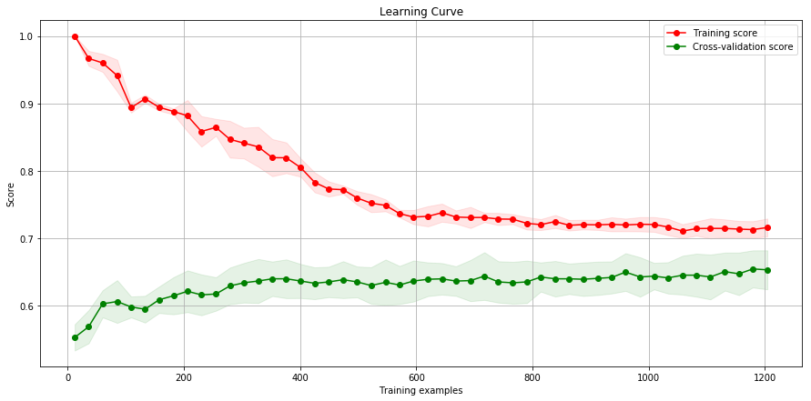

```python
plot_learning_curve(best_linear_svm, "Learning Curve", X_train, y_train, cv=5)
plt.show()
```

Plot shows a typical learning curve: The training score (performance on the training set) decreases with increasing training set size while the validation score increases at the same time. High training score and low validation score at the same time indicates that the model has overfit the data, i.e., has adapted too well to the specific training set samples. As the training set increases, overfitting decreases, and the validation score increases.

It is a typical behaviour for **high bias/low variance model**

```python
Scores.append(score_model(X=X,y=y,clf=best_linear_svm,name="SVM (Linear)"))
Classifiers.append(best_linear_svm)
```

```
Scores:
Name = SVM (Linear)
Accuracy = 0.6286472148541115
Log Loss = 0.8094556689554154
Training Time = 0.4623699188232422
Test Time = 0.06652545928955078
```

### SVM for RBF Kernel

RBF Kernels allows, by the use of kernel trick, to transform the linear separator to make some curves and better fit the problem. The RBF Kernel equivalent to inner product is such defined:

$$RBF = exp(-\gamma \left || x-x_i \right || )$$

```python
rbf_svm = svm.SVC(kernel="rbf",probability=True)
best_rbf_svm = cross_validation(clf=rbf_svm,clf_params=rbf_svm_params,X=X_train,y=y_train)
best_rbf_svm.score(X=X_test, y=y_test)
```

```
Accuracy for result of cross validation: 0.5988063660477454
Cross validation requires: 98.74956679344177 sec
```

```
0.623342175066313
```

```python
Scores.append(score_model(X=X,y=y,clf=best_rbf_svm,name="SVM (RBF)"))
Classifiers.append(best_rbf_svm)
```

```
Scores:
Name = SVM (RBF)
Accuracy = 0.623342175066313
Log Loss = 0.5051902599472488
Training Time = 1.3951194286346436
Test Time = 0.13381648063659668
```

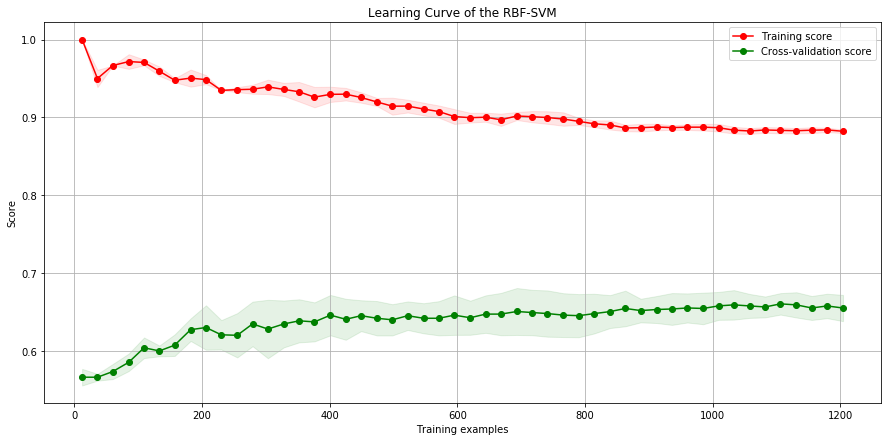

```python
plot_learning_curve(rbf_svm, "Learning Curve of the RBF-SVM", X_train, y_train, cv=5)
plt.show()
```

### SVM with PCA?

```python
score_model(clf=best_rbf_svm,X=pca_X[:,0:n_components],y=y,name="RBF-SVM (PCA)")
score_model(clf=best_linear_svm,X=pca_X[:,0:n_components],y=y,name="Linear SVM (PCA)")
print("------VS------")
score_model(clf=best_rbf_svm,X=X,y=y,name="RBF (whole)")
score_model(clf=best_linear_svm,X=X,y=y,name="linaer (whole)")
print(" ")
```

```
Scores:
Name = RBF-SVM (PCA)
Accuracy = 0.6445623342175066
Log Loss = 0.3666164670689296
Training Time = 1.5515284538269043
Test Time = 0.21601128578186035
Scores:
Name = Linear SVM (PCA)
Accuracy = 0.6472148541114059
Log Loss = 0.8422945861398382
Training Time = 0.6359200477600098
Test Time = 0.10427188873291016
------VS------
Scores:
Name = RBF (whole)
Accuracy = 0.623342175066313
Log Loss = 0.4632471582733335
Training Time = 2.9321603775024414
Test Time = 0.27431416511535645
Scores:
Name = linaer (whole)
Accuracy = 0.6286472148541115
Log Loss = 0.8099027072427306
Training Time = 0.9097933769226074
Test Time = 0.14229702949523926
```

By adding the RBF Kernel, SVM is more adaptive to the nature of the dataset, and for this reason the **high-bias behavior** that mark linear svm is strongly decreased. It is attested also by the learning curve, that appear with *a more relaxed decrement of the training scores* by augmenting the dataset samples.

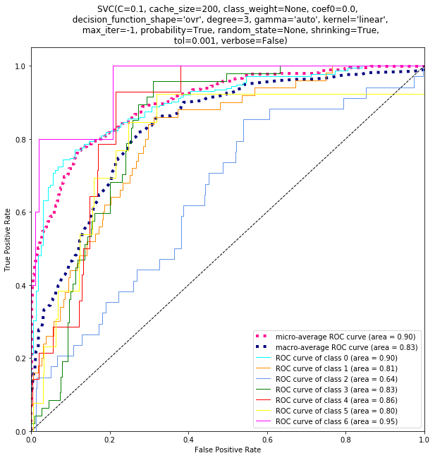

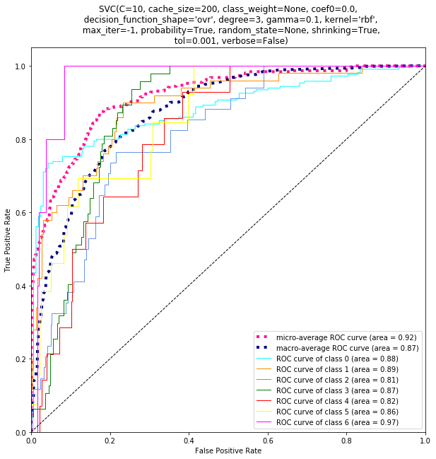

```python
for i,clsf in enumerate([best_linear_svm, best_rbf_svm]):
    plot_multiclass_roc(X=X,clf=clsf,y=y)
```

AUC ROC give us an overview on the performances of the classes in a sort of on-vs-all approach, to graphically display the trend of the classifier **for each single class**

# Comparison

### Performances comparison

```
                                  *****************
                                  Name = RandomForestClassifier
                                  Accuracy = 0.7082228116710876
                                  Log Loss = 0.29112171792981956
                                  Training Time = 2.787353515625
                                  Test Time = 0.45592713356018066
                                  *****************
                                  Name = KNN
                                  Accuracy = 0.6206896551724138
                                  Log Loss = 1.066950619681932
                                  Training Time = 0.004289388656616211
                                  Test Time = 0.30907130241394043
                                  *****************
                                  Name = SVM (Linear)
                                  Accuracy = 0.6286472148541115
                                  Log Loss = 0.8094556689554154
                                  Training Time = 0.4623699188232422
                                  Test Time = 0.06652545928955078
                                  *****************
                                  Name = SVM (RBF)
                                  Accuracy = 0.623342175066313
                                  Log Loss = 0.5051902599472488
                                  Training Time = 1.3951194286346436
                                  Test Time = 0.13381648063659668
```

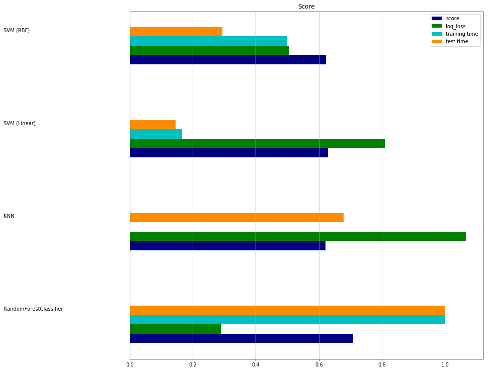

```
Total time spent in classification: 3.7852506302186546
Best accuracy: 0.7082228116710876
Best L.Loss: 0.29112171792981956
```

```python
for scores in Scores:
    print("                                  *****************")
    for name,result in scores:
        print("                                 ",name,"=",result)

scores=[]
for n in range(len(Scores)):
    scores.append(list(zip(*Scores[n]))[1])


# make some plots

indices = np.arange(len(scores))
clf_names = [x[0] for x in scores]
score = [x[1] for x in scores]
log_loss = [x[2] for x in scores]
training_time = [x[3] for x in scores]
test_time = [x[4] for x in scores]
training_time = np.array(training_time) / np.max(training_time)
test_time = np.array(test_time) / np.max(test_time)

plt.figure(figsize=(15, 8))
plt.title("Score")
plt.barh(indices, score, .1, label="score", color='navy')
plt.barh(indices + .1, log_loss, .1, label="log_loss",
         color='g')
plt.barh(indices + .2, training_time, .1, label="training time",
         color='c')
plt.barh(indices + .3, test_time, .1, label="test time", color='darkorange')
plt.yticks(())
plt.grid()
plt.legend(loc='best')
plt.subplots_adjust(left=.25)
plt.subplots_adjust(top=1.25)
plt.subplots_adjust(bottom=.05)

for i, c in zip(indices, clf_names):
    plt.text(-.4, i+.3, c)

plt.show()



print("Total time spent in classification:", np.sum(np.asarray(training_time))+np.sum(np.asarray(test_time)))
print("Best accuracy:",np.max(score))
print("Best L.Loss:",np.min(log_loss))
```